# Assignment

Published

May 18, 2023

# Game of Thrones - Season 4 summary in numbers

### **(*Warning:* spoilers ahead)**

### Overview

(From the [Wikipedia](https://en.wikipedia.org/wiki/Game_of_Thrones#Premise)) Game of Thrones is an American fantasy drama television series created by David Benioff and D. B. Weiss for HBO. It is an adaptation of A Song of Ice and Fire, a series of fantasy novels by George R. R. Martin, the first of which is A Game of Thrones.

Set on the fictional continents of Westeros and Essos, Game of Thrones has a large ensemble cast and follows several story arcs throughout the course of the show. A major arc concerns the Iron Throne of the Seven Kingdoms of Westeros through a web of political conflicts among the noble families either vying to claim the throne or fighting for independence from it. Another focuses on the last descendant of the realm’s deposed ruling dynasty, who has been exiled to Essos and is plotting a return to the throne. A third story arc follows the Night’s Watch, a military order defending the realm against threats from the North.

### Season 4 summary

Season 4 of Game of Thrones consisted of 10 episodes that aired between April 6, 2014 (2014-04-06) and June 15, 2014 (2014-06-15) on HBO. The show gathered an average of 6.846 first-day TV viewers in the US, with the number growing from 6.64 to 7.09 million by the end of the season.

The most popular episode of the season was “Mockingbird”, in which:

> “Cersei appoints Ser Gregor Clegane as her champion in Tyrion’s upcoming trial by combat. Jaime and Bronn decline to fight Ser Gregor for Tyrion, but Oberyn accepts. He seeks to avenge his sister, Elia’s rape and murder by Ser Gregor during the rebellion. Daenerys takes Daario as her lover, then sends him to handle the resurgent slavers at Yunkai. Melisandre and Selyse prepare to depart Dragonstone, intending to take Shireen with them. As the Wildlings approach Castle Black, Alliser Thorne rejects Jon’s suggestion to seal the tunnel. At an inn, Brienne and Podrick meet Hot Pie, who updates them about Arya. They resolve to travel to the Vale, deducing she would seek her living relatives there. In the Vale, Lysa witnesses Littlefinger kissing Sansa. Enraged, she later threatens to throw Sansa through the Moon Door, a circular opening in the stone floor with a steep drop to rocks below; Littlefinger intervenes and shoves Lysa to her death.”

You can see how the viewership of the episodes changed in Figure 1.

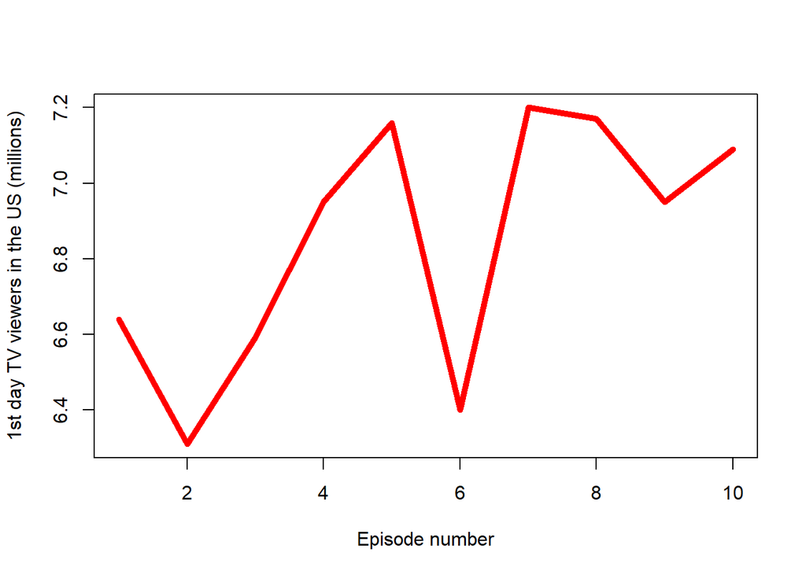

Finally, the episodes with the above-average viewership were:

| No. in season | Title | Directed by |
| --- | --- | --- |
| 4 | “Oathkeeper” | Michelle MacLaren |
| 5 | “First of His Name” | Michelle MacLaren |
| 7 | “Mockingbird” | Alik Sakharov |
| 8 | “The Mountain and the Viper” | Alex Graves |
| 9 | “The Watchers on the Wall” | Neil Marshall |
| 10 | “The Children” | Alex Graves |